# Raminski_UCB_R_Class_Asgt_5

Michael Raminski

Thursday, April 20, 2017

## Diary

For this assignment, I started by doing some background research on Conway’s Game of Life, as I was not familiar with it.

The most confusing part of this game, is the fact that it deals with an infinite plane, even though only a 12 x 12 grid is produced. That makes it impossible to understand how the lives on the border are treated without seeing the squares beyond the grid.

I didn’t find the debugging process to be helpful at all for this assignment, as it did not show any of the results of the variables and tables that were created. Therefore, I had a hard time understanding the results that were expected in each task of this assignment.

I was unable to figure out the code for the last task that would produce the same simulations as the previous run.

## Summary of Results

After testing both codes, I decided to look at the Life4() code. I preferred this code set because it used formulas that were more familiar to me, it was more concise, and it ran more efficiently.

## Assignment

#### Load Life 3

#### Load Life 4

### Task 1 - Differences between the two codes - run system time check

###### There are several differences between the two codes. After testing both codes, I decided to look at the Life4() code. I preferred Life4() to Life3() because the code set was shorter and more concise. Additionally, the formulas used in Life4() were more familiar to me (such as cbind, rbind, etc.) Also, Life4() ran quicker when I compared the “system.time” results of both codes. The difference in “system.time” between the codes was not considerable, although, the fact that Life4() ran a little quicker may suggest that the code is more efficient.

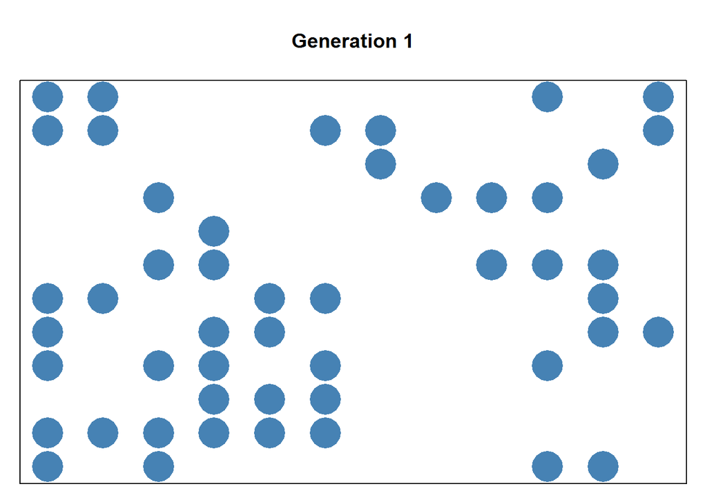

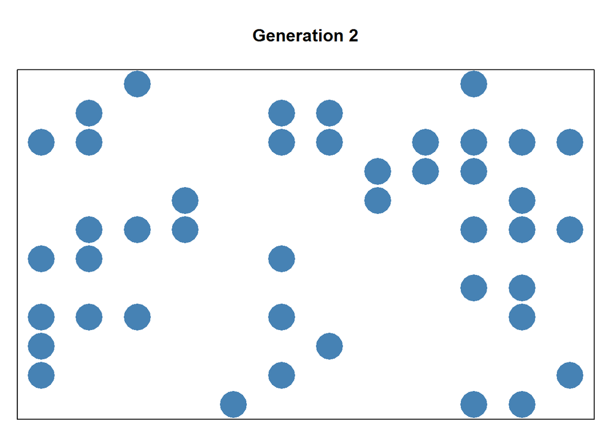

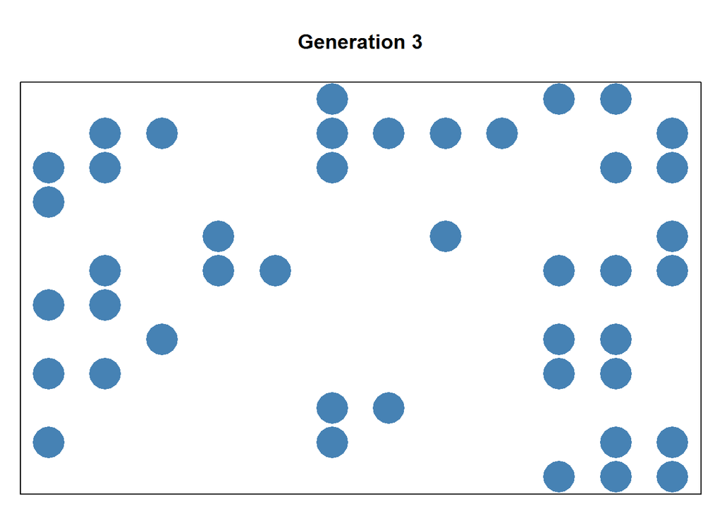

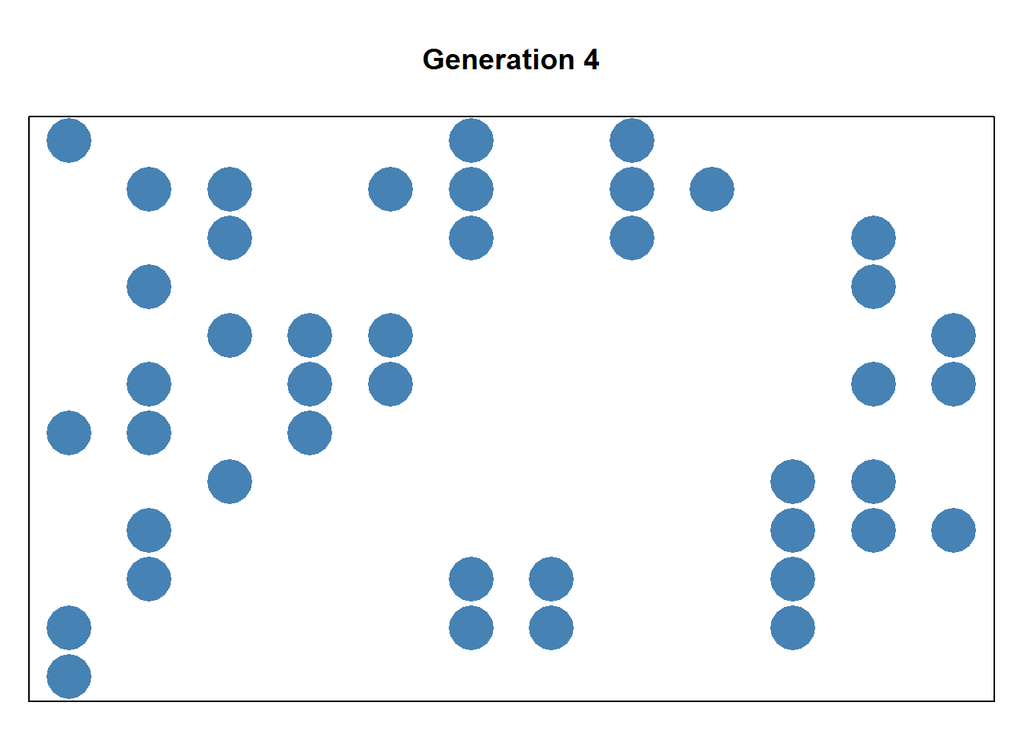

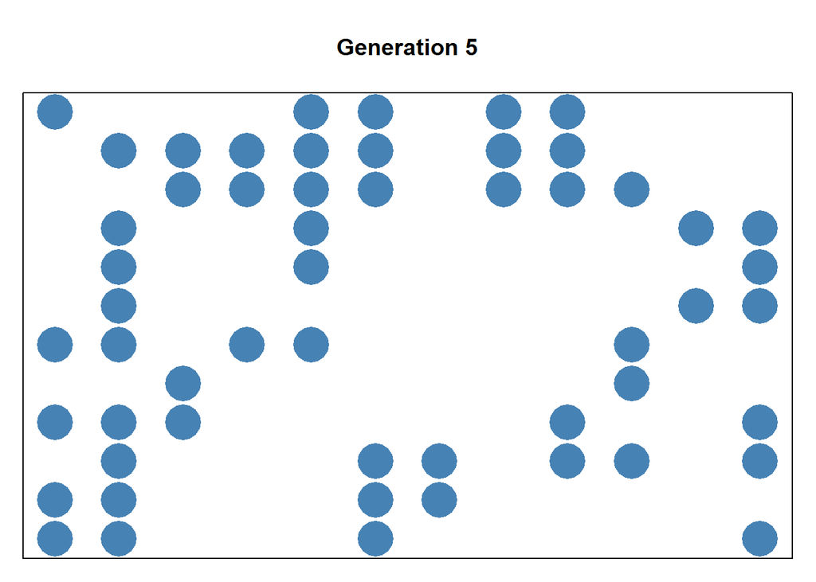

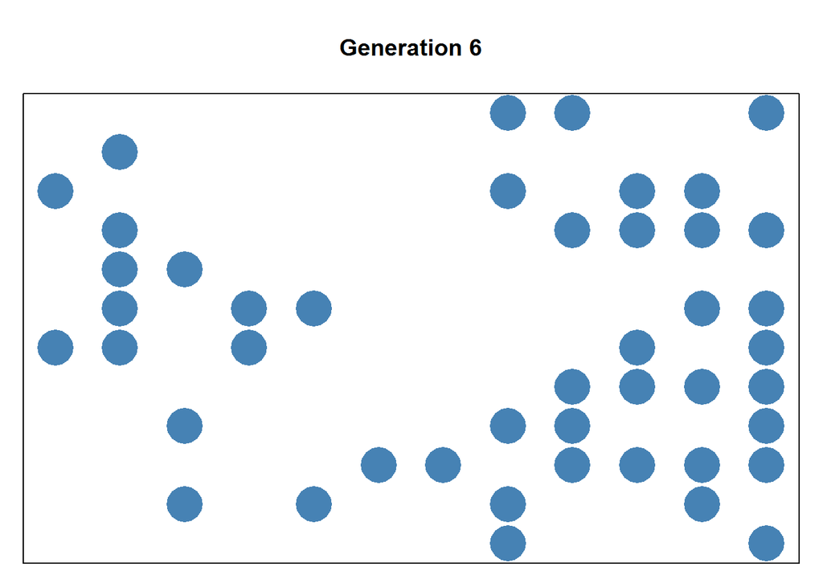

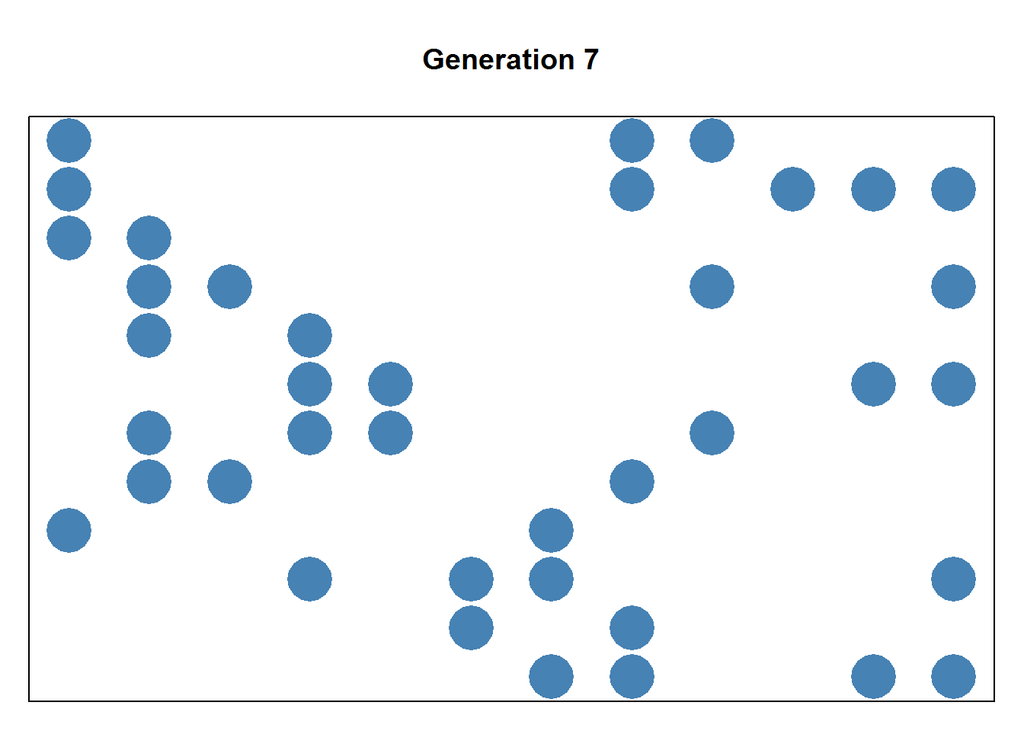

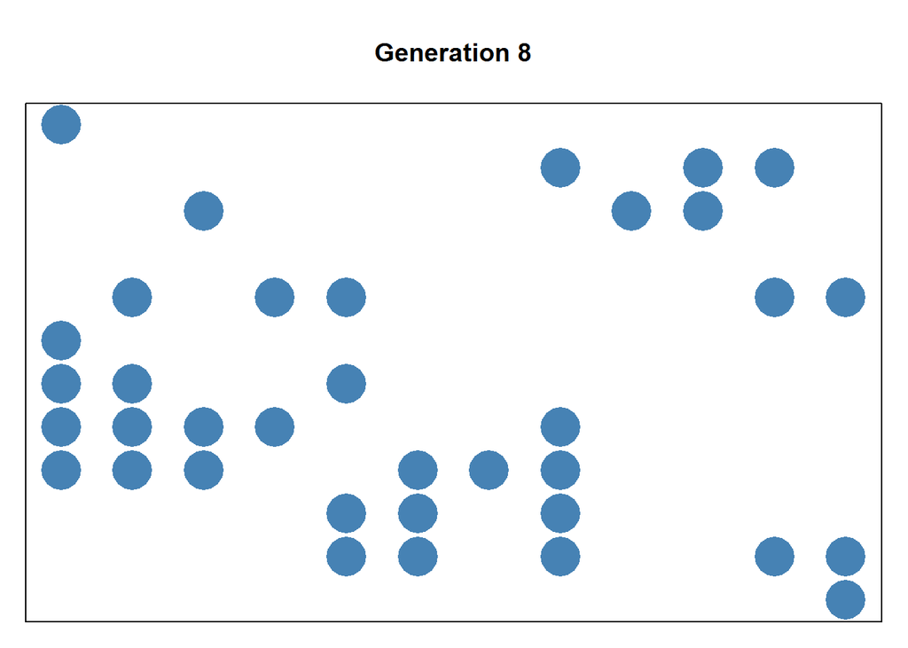

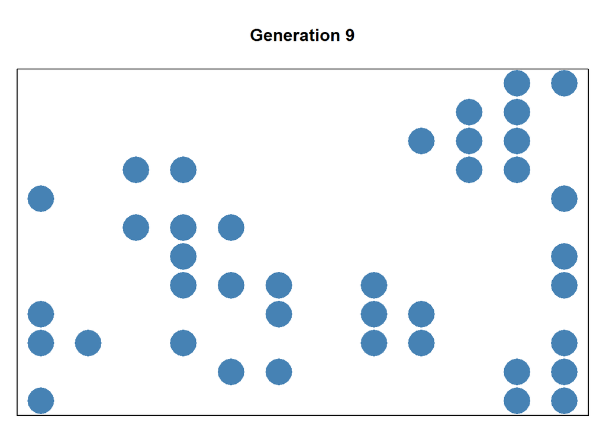

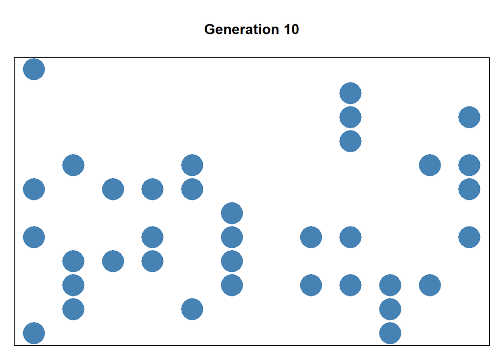

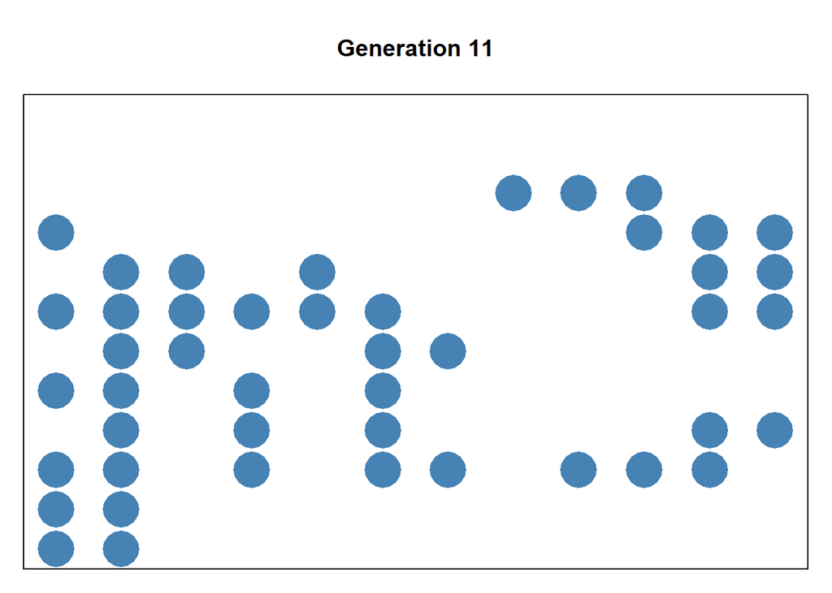

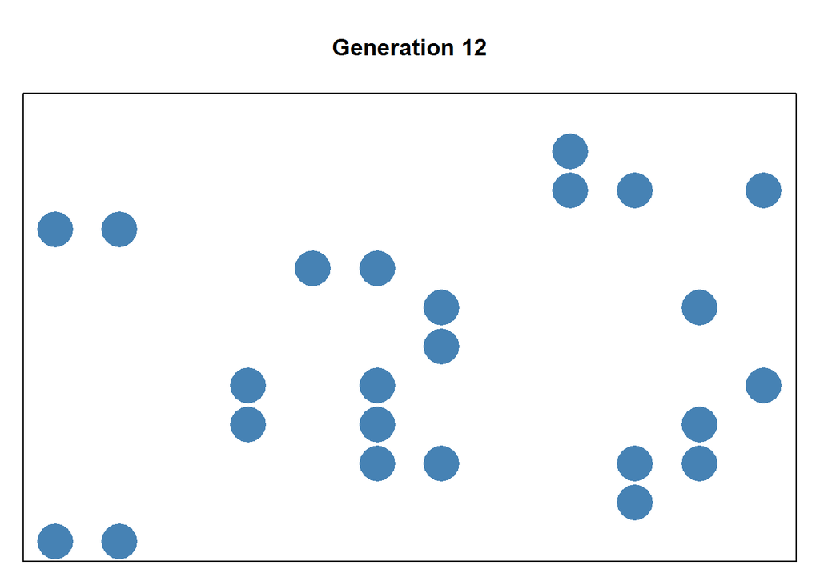

[38 more figures not shown]

```
##    user  system elapsed
##    1.62    0.19    1.81
```

```r
system.time(life3())
```

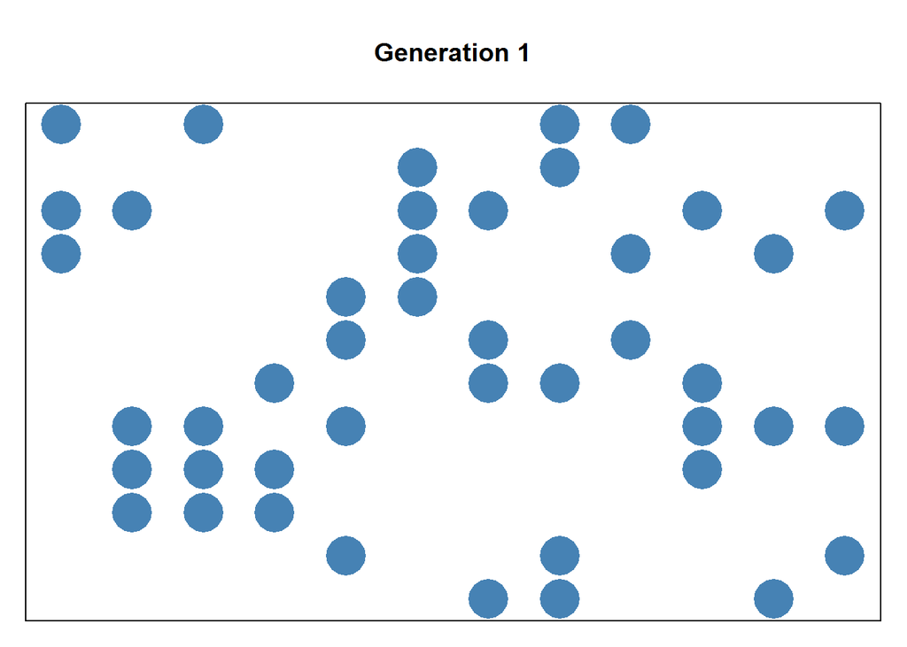

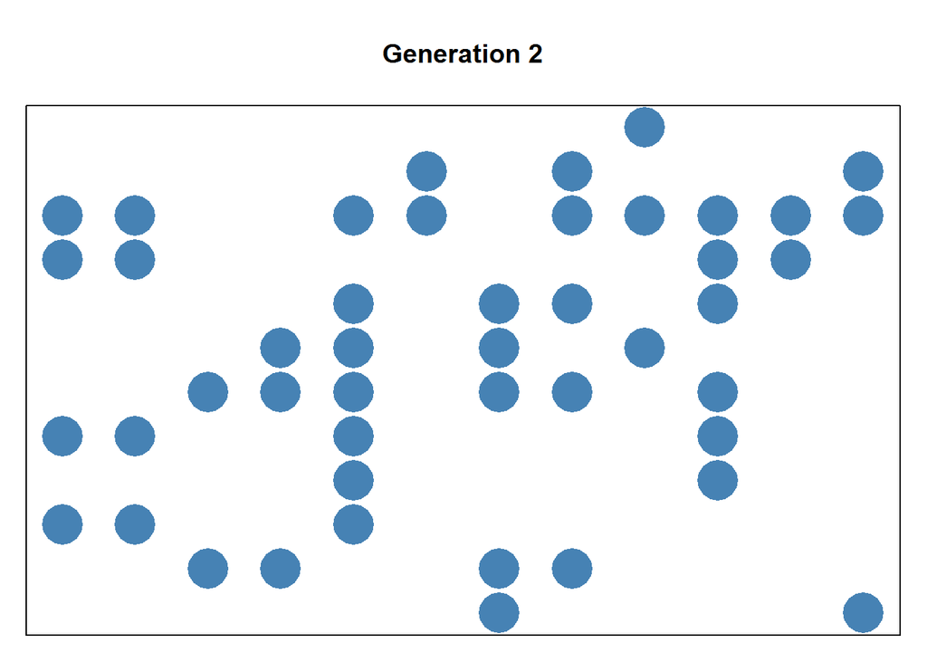

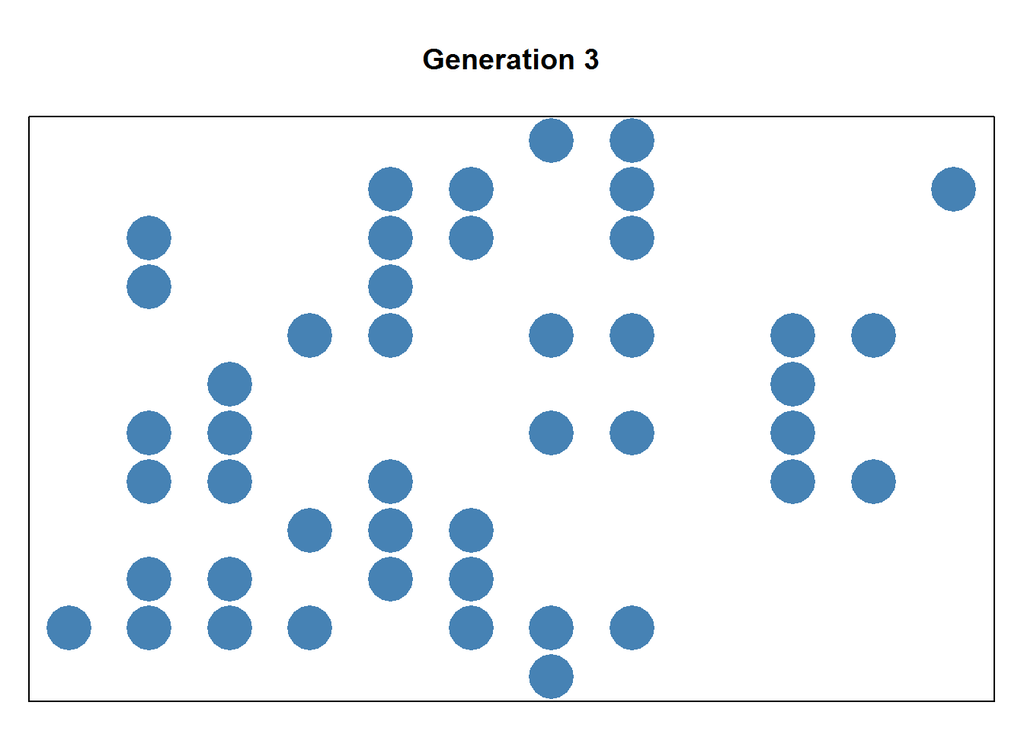

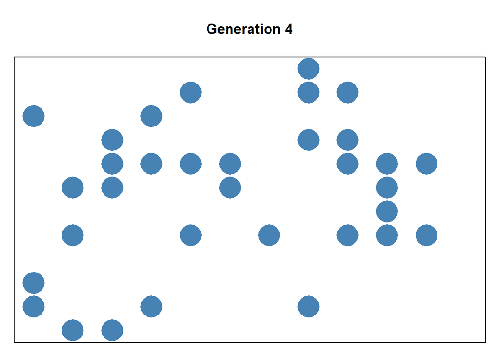

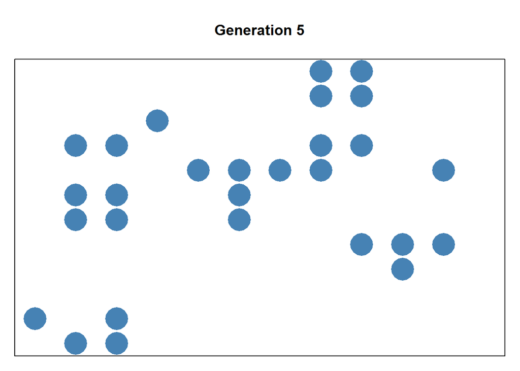

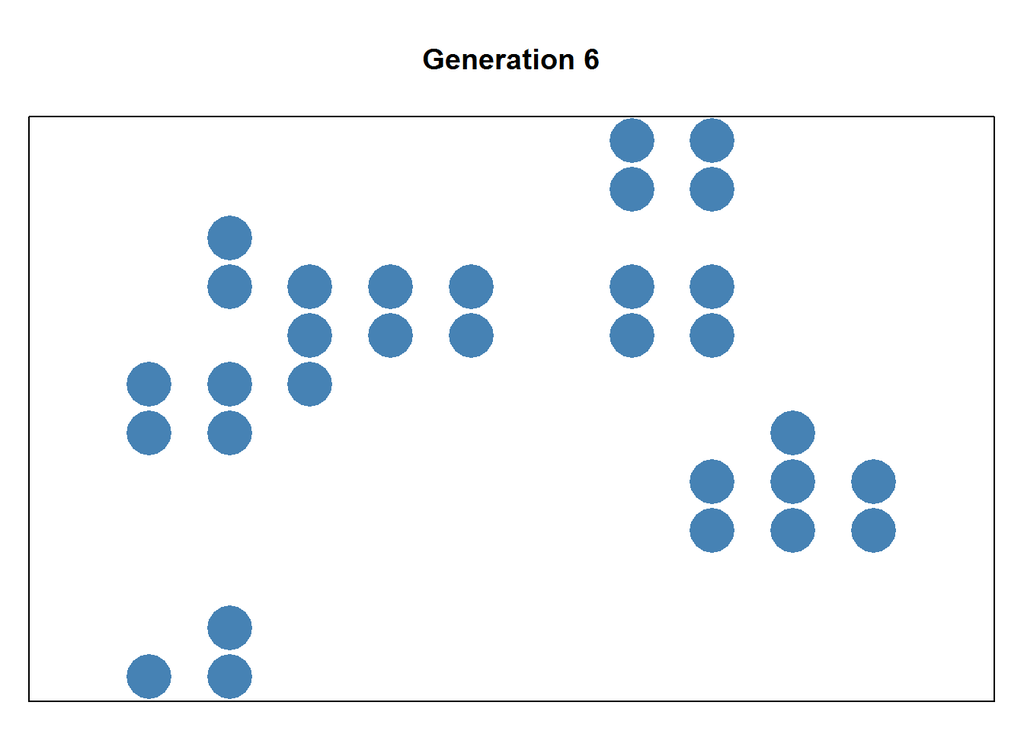

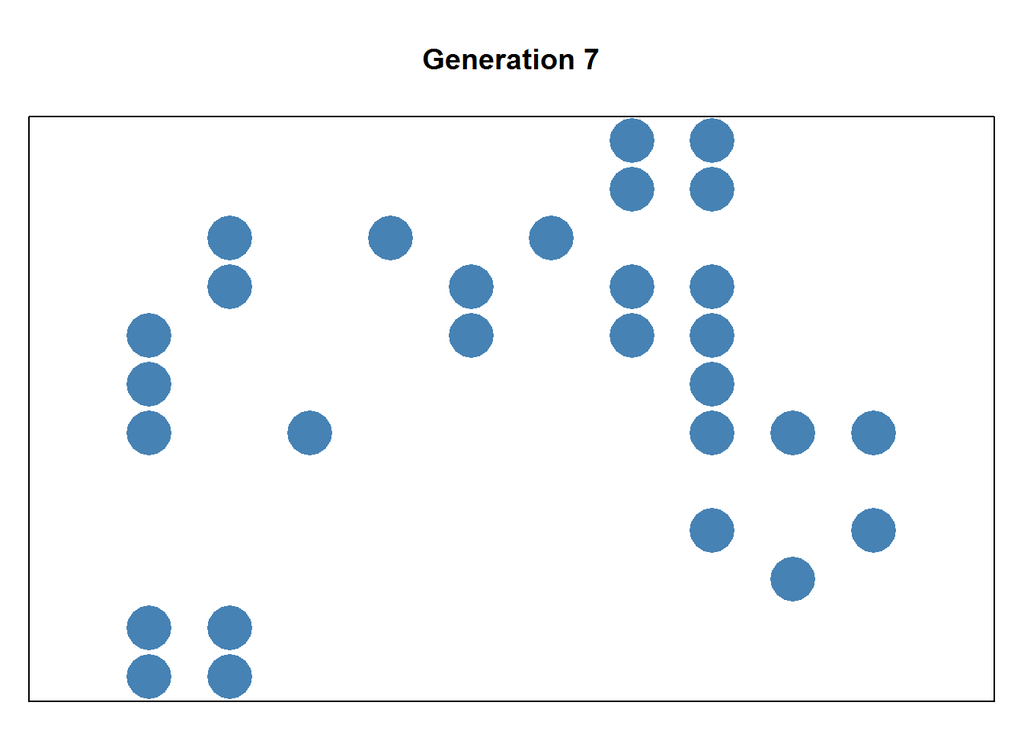

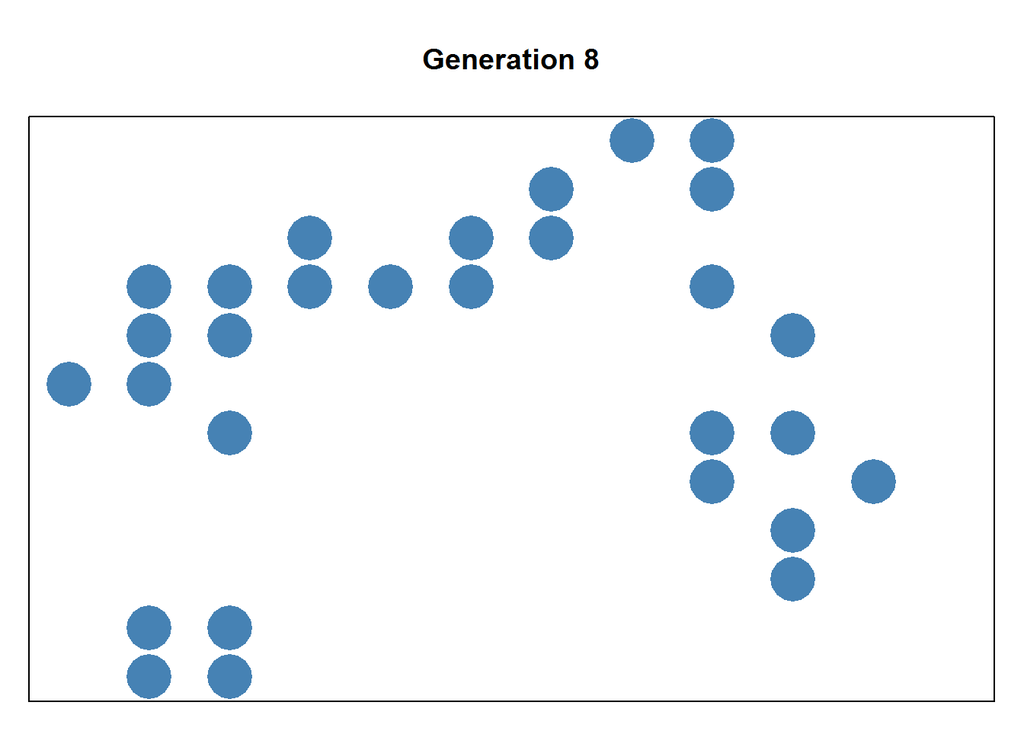

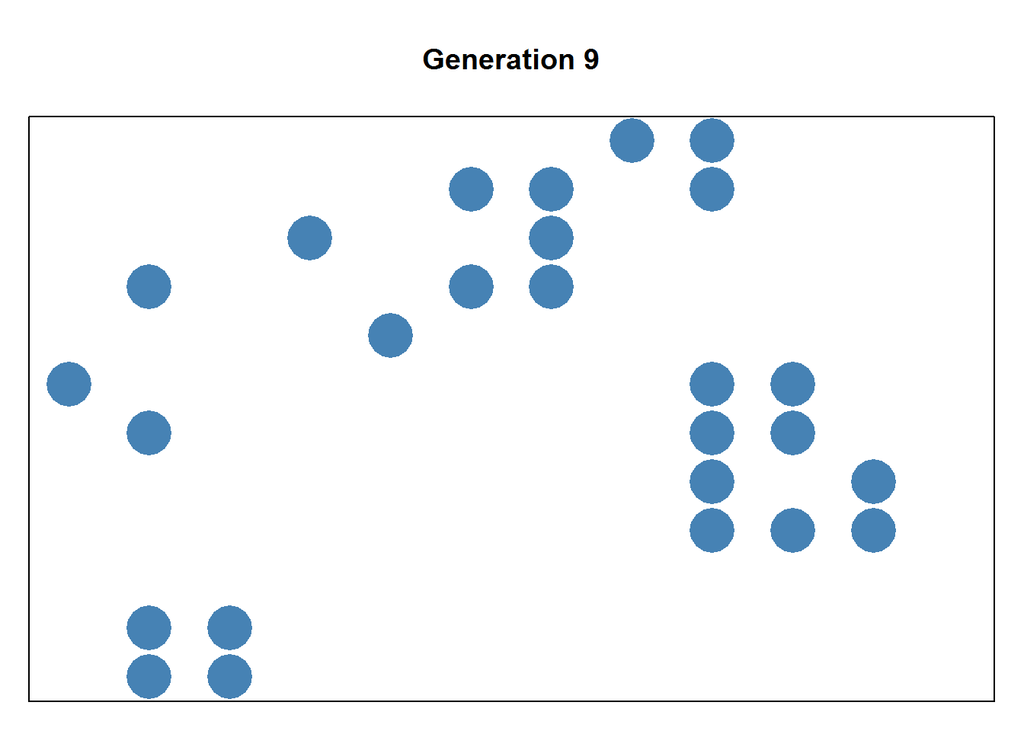

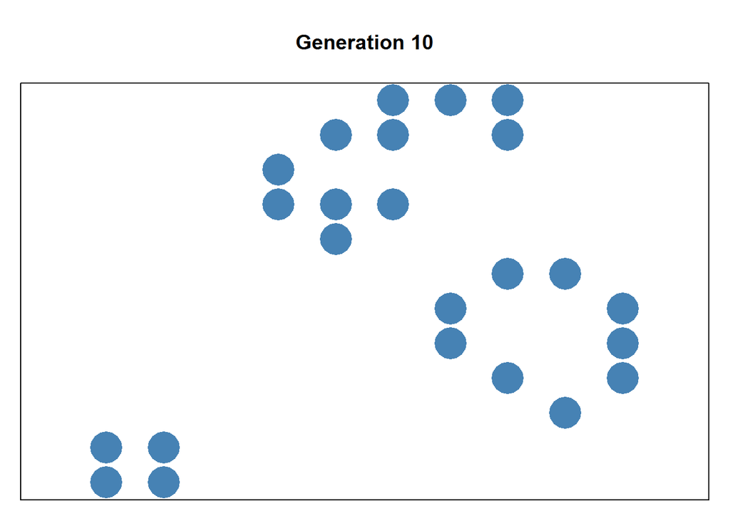

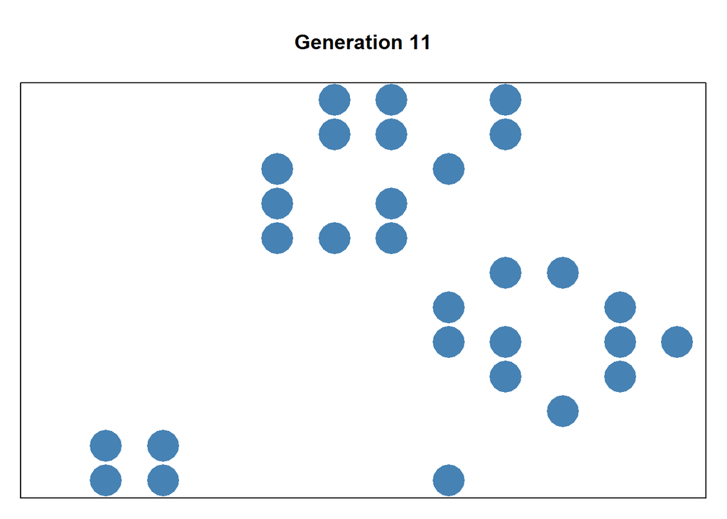

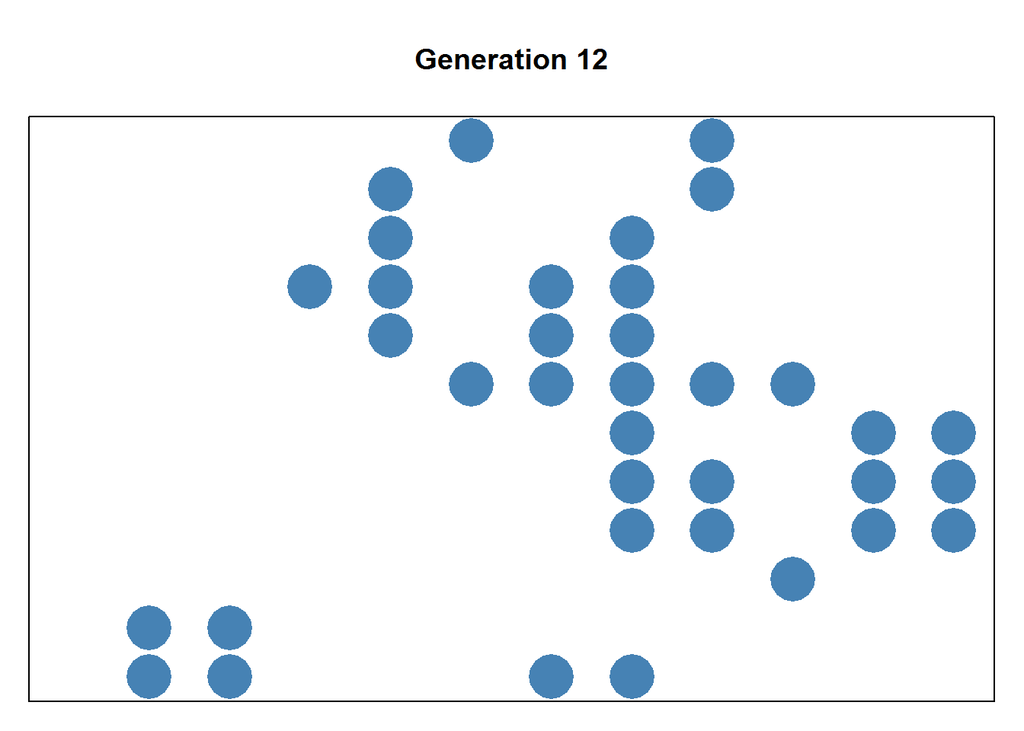

[38 more figures not shown]

```
##    user  system elapsed
##    1.48    0.15    1.63
```

```r
system.time(life4())
```

### Task 2 - Run the debugger to walk through the code

###### I used the debug() function as well as the “Source” button in order to look through various elements of the code. Using debug(plot) allowed to see the innerworkings of that formula.

```r
debug(plot)
undebug(plot)
```